# Project 2: Friday Data

## Introduction:

In this project I will be using the `OnlineNewsPopularity.csv` data, which is a data set about various articles that are published along with various article and publishing attributes. The goal of this project is to accurately predict the number of times that a particular article will be "shared" on social media given its attributes.

## Data Summary

Overall, the Online News Popularity data has *39644* observations and *62* variables. There are a total of *5701* observations for articles that were published on a Friday, and that is the subset of observations that I will be using for this report. From the initial variables, I will be considering *46* of them as potentially having an effect on number of shares.

There are 5 groups of variables that have similar themes in this data set. The variables within each group likely have high correlations with each other. The variable groups are about:

1. Number of words/keywords/media
2. Digital channel type
3. Shares by keyword
4. Typical shares of articles in Mashable
5. Sentiment and Polarity

**Correlation Plots for Number of Word Variables:**

As seen below, many of the variables are highly correlated and might need to be removed.

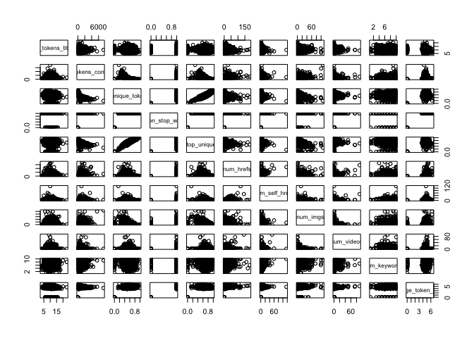

**Shares by Keyword Variables:**

As seen below, many of the variables seem correlated and might need to be removed.

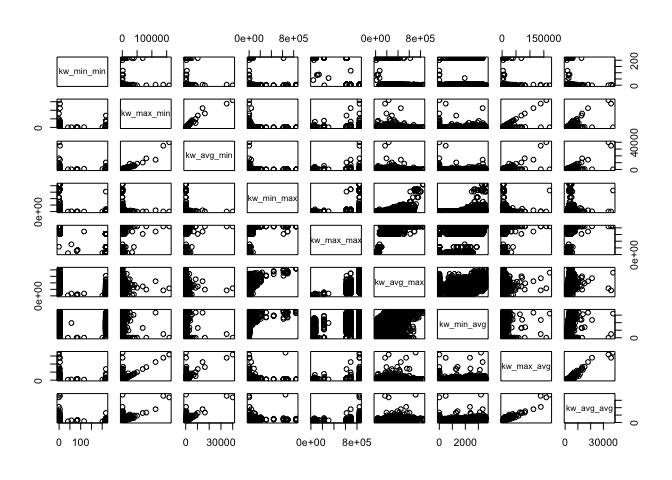

**Mashable Shares Variables:**

These variables seem to have very similar distributions. It is not clear whether there will be any relationship with overall shares.

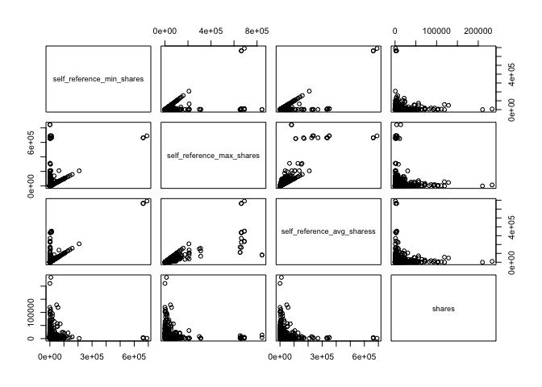

**Sentiment/Polarity Variables:**

When comparing variables measuring positive and negative polarities, there seems to be moderate to strong correlations.

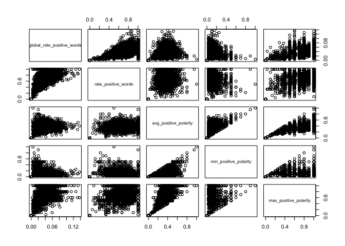

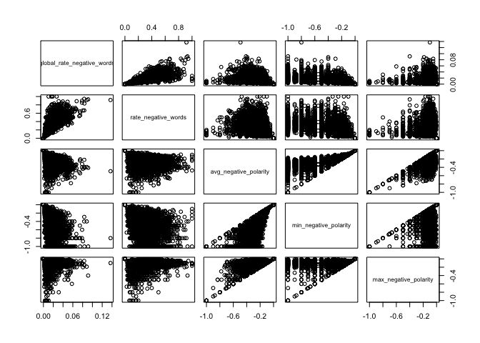

## Modeling

First, I will split the data into training and test sets. The training data set will contain 70% of the data observations, and the test set will contain the remaining 30%.

Dimensions of the train and test sets:

```
## [1] 3990   46

## [1] 1711   46
```

### Linear Model

I will first begin by fitting a linear regression model with ALL of the variables.

```
##
## Call:
## lm(formula = shares ~ ., data = dTrain)
##
## Residuals:
##    Min     1Q Median     3Q    Max
## -11050  -2295  -1133     36 227614
##
## Coefficients: (1 not defined because of singularities)
##                                 Estimate Std. Error t value Pr(>|t|)
## (Intercept)                    2.338e+03  1.944e+03   1.202 0.229323
## n_tokens_title                 1.476e+01  6.929e+01   0.213 0.831326
## n_tokens_content               1.382e+00  5.674e-01   2.436 0.014911 *
## n_unique_tokens                1.001e+04  4.641e+03   2.158 0.031010 *
## n_non_stop_words              -4.791e+03  3.941e+03  -1.215 0.224274
## n_non_stop_unique_tokens      -6.105e+03  3.959e+03  -1.542 0.123154
## num_hrefs                     -5.379e+00  1.608e+01  -0.334 0.738064
## num_self_hrefs                -4.501e+01  4.383e+01  -1.027 0.304421
## num_imgs                      -1.687e+01  2.127e+01  -0.793 0.427607
## num_videos                    -3.519e+00  3.728e+01  -0.094 0.924802
## average_token_length          -1.229e+02  5.786e+02  -0.212 0.831835
## num_keywords                  -1.032e+01  9.078e+01  -0.114 0.909459
## data_channel_is_lifestyle     -1.856e+03  8.083e+02  -2.296 0.021747 *
## data_channel_is_entertainment -1.994e+03  5.971e+02  -3.339 0.000848 ***
## data_channel_is_bus           -1.993e+03  6.520e+02  -3.056 0.002259 **
## data_channel_is_socmed        -9.130e+02  7.753e+02  -1.178 0.239032
## data_channel_is_tech          -1.343e+03  6.374e+02  -2.107 0.035143 *
## data_channel_is_world         -2.173e+03  6.736e+02  -3.225 0.001269 **
## kw_min_min                     2.854e+00  4.191e+00   0.681 0.495926
## kw_max_min                    -6.301e-02  1.330e-01  -0.474 0.635793
## kw_avg_min                    -5.947e-01  6.516e-01  -0.913 0.361476
## kw_min_max                     1.244e-03  3.371e-03   0.369 0.712183
## kw_max_max                     1.133e-03  1.487e-03   0.762 0.445876
## kw_avg_max                    -2.281e-03  2.004e-03  -1.138 0.255219
## kw_min_avg                    -4.255e-01  1.878e-01  -2.266 0.023522 *
## kw_max_avg                     2.779e-03  7.246e-02   0.038 0.969413
## kw_avg_avg                     1.161e+00  3.644e-01   3.186 0.001453 **
## self_reference_min_shares     -2.612e-02  2.213e-02  -1.180 0.237987
## self_reference_max_shares     -3.266e-02  1.458e-02  -2.240 0.025150 *
## self_reference_avg_sharess     7.217e-02  3.445e-02   2.095 0.036272 *
## global_subjectivity            3.392e+03  2.005e+03   1.692 0.090711 .
## global_sentiment_polarity     -1.811e+03  3.868e+03  -0.468 0.639573
## global_rate_positive_words    -1.224e+04  1.724e+04  -0.710 0.477775
## global_rate_negative_words    -5.750e+03  3.167e+04  -0.182 0.855935
## rate_positive_words            1.263e+03  2.659e+03   0.475 0.634873
## rate_negative_words                   NA         NA      NA       NA
## avg_positive_polarity          3.804e+03  3.306e+03   1.151 0.249871
## min_positive_polarity         -4.560e+03  2.675e+03  -1.705 0.088365 .
## max_positive_polarity         -7.532e+01  1.038e+03  -0.073 0.942149
## avg_negative_polarity          1.537e+03  3.047e+03   0.505 0.613888
## min_negative_polarity         -1.636e+03  1.113e+03  -1.470 0.141550
## max_negative_polarity          3.709e+01  2.533e+03   0.015 0.988318
## title_subjectivity             1.648e+02  6.684e+02   0.246 0.805325
## title_sentiment_polarity       1.171e+03  6.099e+02   1.920 0.054958 .
## abs_title_subjectivity        -2.563e+02  8.793e+02  -0.291 0.770743
## abs_title_sentiment_polarity  -9.911e+02  9.785e+02  -1.013 0.311165
## ---
## Signif. codes:  0 '***' 0.001 '**' 0.01 '*' 0.05 '.' 0.1 ' ' 1
##
## Residual standard error: 8793 on 3945 degrees of freedom
## Multiple R-squared:  0.04441,    Adjusted R-squared:  0.03375
## F-statistic: 4.167 on 44 and 3945 DF,  p-value: < 2.2e-16
```

```
##
## Call:
## lm(formula = shares ~ data_channel_is_entertainment + kw_min_min +
##     kw_max_max + kw_avg_max + kw_max_avg + kw_avg_avg + min_positive_polarity,
##     data = dTrain)
##
## Residuals:
##    Min     1Q Median     3Q    Max
## -27356  -2226  -1456   -348 230614
##
## Coefficients:
##                                 Estimate Std. Error t value Pr(>|t|)
## (Intercept)                   -4.024e+02  1.201e+03  -0.335   0.7375
## data_channel_is_entertainment -3.652e+02  3.755e+02  -0.973   0.3309
## kw_min_min                     2.255e+00  4.172e+00   0.541   0.5889
## kw_max_max                     3.217e-04  1.437e-03   0.224   0.8228
## kw_avg_max                    -1.196e-03  1.507e-03  -0.794   0.4274
## kw_max_avg                    -1.476e-01  4.898e-02  -3.014   0.0026 **
## kw_avg_avg                     1.548e+00  2.260e-01   6.850  8.5e-12 ***
## min_positive_polarity         -1.149e+03  1.867e+03  -0.616   0.5382
## ---
## Signif. codes:  0 '***' 0.001 '**' 0.01 '*' 0.05 '.' 0.1 ' ' 1
##
## Residual standard error: 8854 on 3982 degrees of freedom
## Multiple R-squared:  0.02203,    Adjusted R-squared:  0.02031
## F-statistic: 12.82 on 7 and 3982 DF,  p-value: < 2.2e-16
```

Looking at the plots for the model, it seems that there are leverage points affecting the predictions.

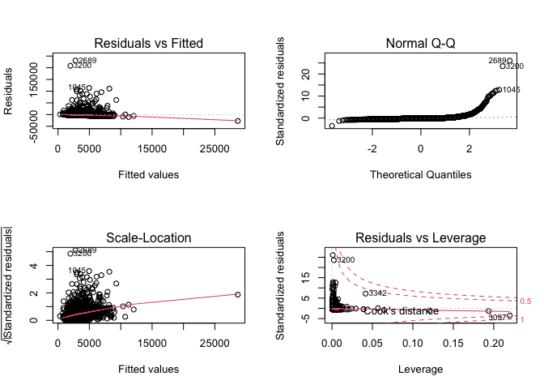

I will now remove the leverage points and create the final linear model. As seen below, the adjusted R<sup>2</sup> has improved a bit for about a 6% explanation of variability, but the RSE has reduced quite a bit. I am assuming that a non-linear model will perform much better for this prediction.

```
##
## Call:
## lm(formula = shares ~ data_channel_is_entertainment + kw_min_min +
##     kw_max_max + kw_avg_max + kw_max_avg + kw_avg_avg + min_positive_polarity,
##     data = dTrain, weights = as.numeric(w))
##
## Weighted Residuals:
##     Min      1Q  Median      3Q     Max
## -4537.1 -1377.1  -777.5   176.5 25916.6
##
## Coefficients:
##                                 Estimate Std. Error t value Pr(>|t|)
## (Intercept)                    7.927e+02  4.034e+02   1.965 0.049500 *
## data_channel_is_entertainment -5.537e+02  1.258e+02  -4.403 1.09e-05 ***
## kw_min_min                     1.088e+00  1.396e+00   0.779 0.435836
## kw_max_max                    -5.486e-05  4.815e-04  -0.114 0.909295
## kw_avg_max                    -1.882e-03  5.116e-04  -3.680 0.000237 ***
## kw_max_avg                    -9.675e-02  2.166e-02  -4.466 8.19e-06 ***
## kw_avg_avg                     9.789e-01  8.049e-02  12.162  < 2e-16 ***
## min_positive_polarity         -1.818e+03  6.591e+02  -2.759 0.005829 **
## ---
## Signif. codes:  0 '***' 0.001 '**' 0.01 '*' 0.05 '.' 0.1 ' ' 1
##
## Residual standard error: 2929 on 3898 degrees of freedom
## Multiple R-squared:  0.06061,    Adjusted R-squared:  0.05893
## F-statistic: 35.93 on 7 and 3898 DF,  p-value: < 2.2e-16
```

### Non-Linear Models

First, I will fit a simple Regression Tree in order to predict shares. Here is the code below:

```r
set.seed(100)
trctrl <- trainControl(method="repeatedcv", number=10, repeats = 3)
metric = 'RMSE'
tree_fit <- train(shares ~., data = dTrain, method = "rpart", metric = metric, trControl = trctrl,
                 preProcess = c("center", "scale") )
```

I will also fit a bagged tree to predict shares. Here is the code for that:

```r
bag_fit <- train(shares ~., data = dTrain, method = "treebag", metric = metric, trControl = trctrl,
                 preProcess = c("center", "scale") )
```

## Test Set Prediction

I will fit each of the 3 models (Linear Regression, Regression Tree, Bagged Tree) on the test data set.

Here are the corresponding RMSE values:

- The RMSE for the Linear Regression model on the test set is 5842.5499568.
- The RMSE for the Regression Tree model on the test set is 5892.3879557.
- The RMSE for the Bagged Tree model on the test set is 5882.4349044.

## Conclusion

Comparing the linear and non-linear methods based on test MSE, the Linear Regression model performed the best in predicting number of shares, despite having a high MSE and low adjusted R<sup>2</sup> on its own.